# Assignment 3: Model comparison

Marton Kovacs

In this lab assignment you are going to work with (simulated) data related to perioperative pain and its psychological and hormonal predictors. In the assignment you will assess the added benefit of including some psychological and hormonal predictors to the already established demographic predictors of pain.

In this assignment you will set up a hierarchical regression model to predict postoperative pain after wisdom tooth surgery.

# Research problem

The amount of pain experienced around and after surgeries are highly variable between and within individuals. In order to improve surgical pain management regimens we need to understand what influences pain around surgical procedures and predict the amount of pain an individual will experience.

Your first study in this area is related to assessing the influence of trait and state psychological measures on pain, and to see whether taking into account these variables can improve our understanding of postoperative pain.

# Procedures and measures

Use the data file called ‘assignment_3_dataset’, from the ‘data/’ folder.

You have collected data from 160 adults who were scheduled to undergo surgical extraction of the third mandibular molar (wisdom tooth surgery). Patients filled out a form in the waiting room before their surgery. The form contained questions about their sex, age, and weight, and psychological questionnaires assessing anxiety, pain catastrophizing, and mindfulness (see descriptions below). You also got blood samples and saliva samples from participants in the waiting room 5 minutes before their operations to determine the serum (a component of the blood) and salivary cortisol levels of participants. Participants were contacted 5 hours after the surgery to see how much pain they were experiencing. The **level of pain** at that moment was recorded using a numerical rating scale using a **scale of 0 to 10**, where 0 means “no pain” and 10 means “worst pain I can imagine”.

**The State Trait Anxiety Inventory:** T measures trait anxiety on a scale of 20 to 80, higher scores mean higher anxiety. Anxiety has been found in many studies to positively correlate with the level of pain experienced. This is **variable STAI_trait** in the dataset.

**The Pain Catastrophizing Scale** measures the extent of pain catastrophizing, which is characterized by a tendency to magnify the threat value of a pain stimulus and to feel helpless in the presence of pain, as well as by a relative inability to prevent or inhibit pain-related thoughts in anticipation of, during, or following a painful event. The total score on this scale ranges from 0 to 52, higher scores mean higher catastrophizing. Pain catastrophizing is one of the well-established predictors of clinical pain. This is **variable pain_cat** in the dataset.

**The Mindful Attention Awareness Scale (MAAS)** measures dispositional mindfulness, which may be described as a tendency to turn attention to present-moment experiences in an open, non-judgmental way. The MAAS total score ranges from 1 to 6 (an average of the item scores), with higher scores representing higher dispositional mindfulness. Trait mindfulness has been theorized to serve as a protective factor against pain, as the individual would be more objective about their pain experience and tend to associate less discomfort, despair, and hopelessness to the pain-related sensations. This is **variable mindfulness** in the dataset.

**Cortisol** is a stress hormone associated with acute and chronic stress. Cortisol levels are thought to be positively associated with pain experience. Cortisol can be **measured from both blood and the saliva**, although, serum cortisol is often regarded in medical research as more reliably related to stress (serum is a component of the blood plasma). These are **variables cortisol_serum**, and **cortisol_saliva** in the dataset.

# Research question

Previous studies and meta-analyses showed that age and sex are often predictors of pain (age is negatively associated with pain, while sex is a predictor more dependent on the type of the procedure). You would like to determine the extent to which taking into account psychological and hormonal variables aside from the already used demographic variables would improve our understanding of postoperative pain.

To answer this research question you will **need to compare two models** (with a hierarchical regression). The **simpler model** should contain **age and sex as predictors of pain**, while the **more complex model** should contain the **predictors: age, sex, STAI, pain catastrophizing, mindfulness, and cortisol measures**. Notice that the predictors used in the simpler model are a subset of the predictors used in more complex model. **You will have to do model comparison to assess whether substantial new information was gained about pain in the more complex model compared to the simpler model.**

# What to report

As usual, before you can interpret your model, you will need to run data and model diagnostics. First, check the variables included in the more complex model (age, sex, STAI, pain catastrophizing, mindfulness, and cortisol measures as predictors, and pain as an outcome) for **coding errors**, and the model itself for **influential outliers** (for example using Cook’s distance). Furthermore, check the final model to see if the **assumptions of linear regression hold true**, that is, **normality** (of the residuals), **linearity** (of the relationship), **homogeneity of variance** (also called homoscedasticity) and that there is no excess **multicollinearity** (“uncorrelated predictors” in Navarro’s words). If you find anything amiss during these checks, make the appropriate decision or correction and report your findings and actions in your report.

**Note:** If you do any changes, such as exclude cases, or exclude predictors from the model, you will have to re-run the above checks for your final data and model.

Report the results of the simpler model and the more complex model. For both models you should report the model test statistics (adj.R2, F, df, and p value). Also, report the statistics describing the coefficients of the predictors in a table format (unstandardized regression coefficients and 95% confidence intervals, standardized regression coefficients (B and Beta values), and p values).

# What to discuss

In your discussion of the findings, briefly interpret the results of the above analyses, and indicate whether you think that anything was gained by including the psychological and hormone measures in the model.

# Solution

```r
library(tidyverse)
library(lmtest)
library(car)
```

## Read the data

Read the dataset used in this assignment. Pay attention to the extension of the datafile.

```r
#reading the excel file
dataset<- readxl::read_excel("/Users/ferenczboroka/Desktop/R-project/Fall-2024/data/assignment_3_dataset_.xlsx")
```

## Data and model diagnostics

### Data diagnostics

#### Descriptives of the variables

Run an exploratory data analysis (EDA) to investigate the dataset.

```r
summary(dataset)
```

```
##       ID                 pain            sex                 age
##  Length:160         Min.   : 1.000   Length:160         Min.   :24.00
##  Class :character   1st Qu.: 4.000   Class :character   1st Qu.:38.00
##  Mode  :character   Median : 5.000   Mode  :character   Median :41.00
##                     Mean   : 5.194                      Mean   :40.74
##                     3rd Qu.: 6.000                      3rd Qu.:44.00
##                     Max.   :50.000                      Max.   :53.00
##    STAI_trait       pain_cat     cortisol_serum  cortisol_saliva
##  Min.   :26.00   Min.   :14.00   Min.   :2.700   Min.   :2.530
##  1st Qu.:37.00   1st Qu.:27.00   1st Qu.:4.268   1st Qu.:4.120
##  Median :40.00   Median :30.00   Median :4.995   Median :5.035
##  Mean   :40.09   Mean   :29.88   Mean   :4.941   Mean   :4.952
##  3rd Qu.:43.00   3rd Qu.:32.25   3rd Qu.:5.633   3rd Qu.:5.753
##  Max.   :52.00   Max.   :42.00   Max.   :7.110   Max.   :7.190
##   mindfulness        weight            IQ         household_income
##  Min.   :1.000   Min.   :33.80   Min.   : 52.00   Min.   :  5548
##  1st Qu.:2.595   1st Qu.:62.15   1st Qu.: 91.75   1st Qu.: 53489
##  Median :3.115   Median :68.77   Median :101.00   Median : 72149
##  Mean   :3.204   Mean   :68.57   Mean   :100.74   Mean   : 70426
##  3rd Qu.:3.830   3rd Qu.:74.65   3rd Qu.:109.00   3rd Qu.: 87734
##  Max.   :6.220   Max.   :97.13   Max.   :144.00   Max.   :139268
```

```r
#checking  missing values
colSums(is.na(dataset))
```

```
##               ID             pain              sex              age
##                0                0                0                0
##       STAI_trait         pain_cat   cortisol_serum  cortisol_saliva
##                0                0                0                0
##      mindfulness           weight               IQ household_income
##                0                0                0                0
```

```r
#checking correlations
cor_matrix <- cor(dataset[, c("pain", "age", "STAI_trait", "pain_cat", "cortisol_serum", "cortisol_saliva", "mindfulness")], use = "complete.obs")
print(cor_matrix)
```

```
##                       pain        age STAI_trait   pain_cat cortisol_serum
## pain             1.0000000 -0.1116972  0.1519405  0.1874959      0.2566994
## age             -0.1116972  1.0000000  0.1360351 -0.2913113     -0.2792927
## STAI_trait       0.1519405  0.1360351  1.0000000  0.4730655      0.4518784
## pain_cat         0.1874959 -0.2913113  0.4730655  1.0000000      0.4130465
## cortisol_serum   0.2566994 -0.2792927  0.4518784  0.4130465      1.0000000
## cortisol_saliva  0.2753366 -0.3120898  0.4888753  0.3664581      0.9090115
## mindfulness     -0.1144317 -0.0137782 -0.4814423 -0.4987234     -0.3333231
##                 cortisol_saliva mindfulness
## pain                  0.2753366  -0.1144317
## age                  -0.3120898  -0.0137782
## STAI_trait            0.4888753  -0.4814423
## pain_cat              0.3664581  -0.4987234
## cortisol_serum        0.9090115  -0.3333231
## cortisol_saliva       1.0000000  -0.3349702
## mindfulness          -0.3349702   1.0000000
```

```r
#checking the sex variable
table(dataset$sex)
```

```
##
## female   male  woman
##     83     76      1
```

```r
#ranges
range(dataset$STAI_trait)
```

```
## [1] 26 52
```

```r
range(dataset$pain_cat)
```

```
## [1] 14 42
```

```r
range(dataset$mindfulness)
```

```
## [1] 1.00 6.22
```

#### Correct coding errors

If you find values in the dataset during the EDA, that are not correct based on the provided descriptions of the variables of the dataset please correct them here.

```r
# Recode the 'sex' variable
dataset <- dataset %>%
  mutate(sex = ifelse(sex == "woman", "female", sex))

# Check the unique values to confirm
unique(dataset$sex)
```

```
## [1] "female" "male"
```

```r
filtered_data <- dataset %>%
  filter(pain >= 1 & pain <= 10)

# Check the filtered data
summary(filtered_data$pain)
```

```
##    Min. 1st Qu.  Median    Mean 3rd Qu.    Max.
##   1.000   4.000   5.000   4.912   6.000   8.000
```

```r
final_dataset <- filtered_data %>%
  filter(mindfulness >= 1 & mindfulness <= 6)

# Check the filtered data
summary(final_dataset$mindfulness)
```

```
##    Min. 1st Qu.  Median    Mean 3rd Qu.    Max.
##   1.000   2.585   3.110   3.185   3.830   5.630
```

### Model diagnostics

#### Build the more complex model

In order to test the more complex model for outliers and to test the assumptions first build the model.

```r
# Complex model with multiple predictors
model_complex <- lm(pain ~ age + sex + STAI_trait + pain_cat + mindfulness + cortisol_saliva + cortisol_serum, data = final_dataset)
summary(model_complex)
```

```
##
## Call:
## lm(formula = pain ~ age + sex + STAI_trait + pain_cat + mindfulness +
##     cortisol_saliva + cortisol_serum, data = final_dataset)
##
## Residuals:
##     Min      1Q  Median      3Q     Max
## -3.2406 -0.7463 -0.0537  0.7906  2.9380
##
## Coefficients:
##                 Estimate Std. Error t value Pr(>|t|)
## (Intercept)      1.29880    1.72907   0.751  0.45374
## age             -0.02142    0.02447  -0.875  0.38292
## sexmale          0.32267    0.21118   1.528  0.12863
## STAI_trait      -0.02814    0.02821  -0.998  0.32010
## pain_cat         0.09370    0.02889   3.243  0.00146 **
## mindfulness     -0.11768    0.12620  -0.933  0.35257
## cortisol_saliva  0.44738    0.25296   1.769  0.07900 .
## cortisol_serum   0.16818    0.24576   0.684  0.49482
## ---
## Signif. codes:  0 '***' 0.001 '**' 0.01 '*' 0.05 '.' 0.1 ' ' 1
##
## Residual standard error: 1.244 on 150 degrees of freedom
## Multiple R-squared:  0.3516, Adjusted R-squared:  0.3213
## F-statistic: 11.62 on 7 and 150 DF,  p-value: 9.351e-12
```

#### Checking for influential outliers

Check for outlier values in the model.

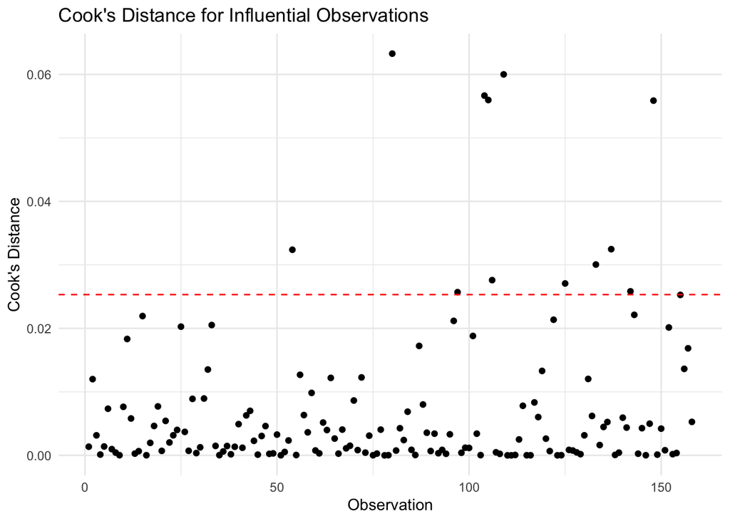

```r
# Check for influential points using Cook's distance
cooks_d <- cooks.distance(model_complex)

# Visualize Cook's Distance
cooks_data <- data.frame(Observation = 1:length(cooks_d), Cooks_Distance = cooks_d)

ggplot(cooks_data, aes(x = Observation, y = Cooks_Distance)) +
  geom_point() +
  geom_hline(yintercept = 4 / length(cooks_d), color = "red", linetype = "dashed") +
  labs(title = "Cook's Distance for Influential Observations",
       x = "Observation",
       y = "Cook's Distance") +
  theme_minimal()
```

```r
# Identify observations with Cook's distance greater than 4/n (rule of thumb)
influentials <- which(cooks_d > (4 / nrow(final_dataset)))
influentials
```

```
##  54  80  97 104 105 106 109 125 133 137 142 148
##  54  80  97 104 105 106 109 125 133 137 142 148
```

#### Checking assumptions

Check the normality assumption.

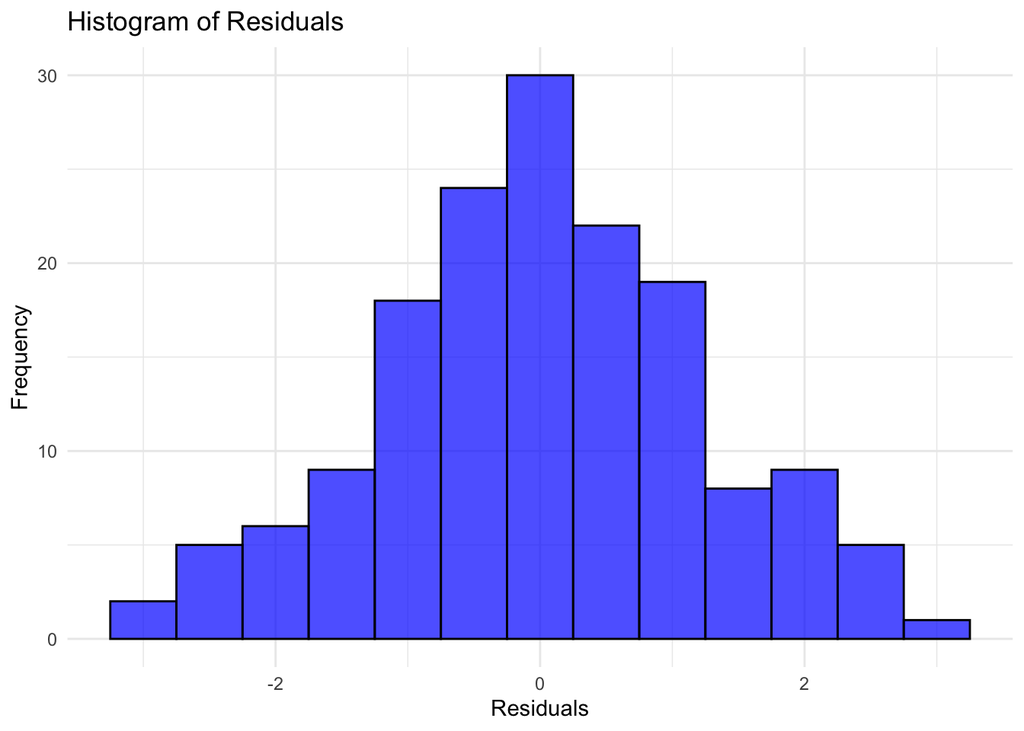

```r
# Calculate residuals
residuals_model <- residuals(model_complex)

# Plot histogram
ggplot(data.frame(residuals = residuals_model), aes(x = residuals)) +
  geom_histogram(binwidth = 0.5, color = "black", fill = "blue", alpha = 0.7) +
  labs(title = "Histogram of Residuals", x = "Residuals", y = "Frequency") +
  theme_minimal()
```

```r
# Shapiro-Wilk normality test
shapiro.test(residuals_model)
```

```
##
##  Shapiro-Wilk normality test
##
## data:  residuals_model
## W = 0.99422, p-value = 0.788
```

Check the linearity assumption.

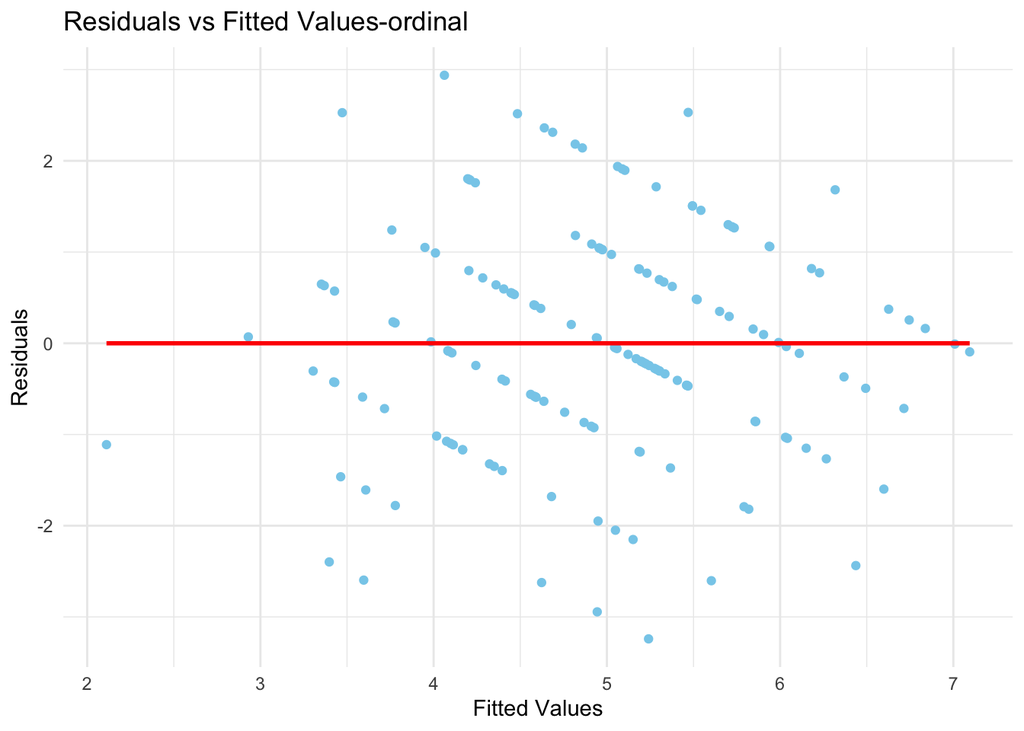

```r
# Get the fitted values
fitted_values <- fitted(model_complex)

# Create a data frame for ggplot
residuals_vs_fitted_df <- data.frame(fitted_values, residuals = residuals(model_complex))

# Residuals vs Fitted plot using ggplot2
ggplot(residuals_vs_fitted_df, aes(x = fitted_values, y = residuals)) +
  geom_point(color = "skyblue") +
  geom_smooth(method = "lm", color = "red", se = FALSE) +  # Optional: Add a linear trend line
  labs(title = "Residuals vs Fitted Values-ordinal", x = "Fitted Values", y = "Residuals") +
  theme_minimal()
```

Check the homoscedasticty assumption (homogeneity of variance).

```r
# Breusch-Pagan Test for homoscedasticity
bptest(model_complex)
```

```
##
##  studentized Breusch-Pagan test
##
## data:  model_complex
## BP = 6.7628, df = 7, p-value = 0.454
```

Check the multicollinearity assumption.

Some info about VIF: https://statisticalhorizons.com/multicollinearity http://blog.minitab.com/blog/understanding-statistics/handling-multicollinearity-in-regression-analysis

```r
# Calculate and check the VIF for the complex model
vif_values <- vif(model_complex)

# Print VIF values
print(vif_values)
```

```
##             age             sex      STAI_trait        pain_cat     mindfulness
##        1.537752        1.134642        2.056568        1.836336        1.466876
## cortisol_saliva  cortisol_serum
##        6.594781        6.020413
```

### Making decision based on model diagnostics

If based on the assumption tests you decide to drop a predictor variable you should do that here. Create your updated model.

```r
#I decided to keep influential outliers because they might be important to understand in this context, and they don't have an effect on the assumptions
# Complex model with additional predictors
new_model_complex <- lm(pain ~ age + sex + STAI_trait + pain_cat + mindfulness + cortisol_saliva, data = final_dataset)
summary(new_model_complex)
```

```
##
## Call:
## lm(formula = pain ~ age + sex + STAI_trait + pain_cat + mindfulness +
##     cortisol_saliva, data = final_dataset)
##
## Residuals:
##     Min      1Q  Median      3Q     Max
## -3.3126 -0.7090 -0.0763  0.7986  3.0697
##
## Coefficients:
##                 Estimate Std. Error t value Pr(>|t|)
## (Intercept)      1.26406    1.72528   0.733 0.464897
## age             -0.01983    0.02432  -0.815 0.416079
## sexmale          0.31755    0.21067   1.507 0.133814
## STAI_trait      -0.02995    0.02803  -1.068 0.287073
## pain_cat         0.09812    0.02811   3.491 0.000632 ***
## mindfulness     -0.11636    0.12596  -0.924 0.357079
## cortisol_saliva  0.59683    0.12744   4.683 6.24e-06 ***
## ---
## Signif. codes:  0 '***' 0.001 '**' 0.01 '*' 0.05 '.' 0.1 ' ' 1
##
## Residual standard error: 1.242 on 151 degrees of freedom
## Multiple R-squared:  0.3496, Adjusted R-squared:  0.3237
## F-statistic: 13.53 on 6 and 151 DF,  p-value: 2.995e-12
```

#### Checking outliers of the updated model

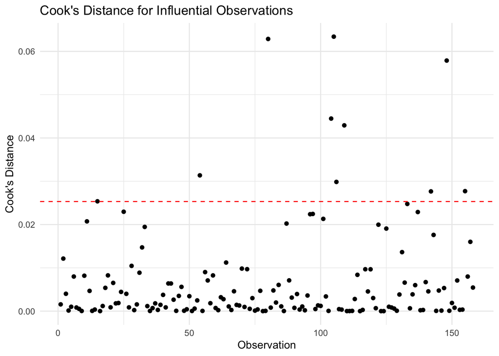

```r
# Calculate Cook's distance
cooks_d2 <- cooks.distance(new_model_complex)

# Visualize Cook's Distance
cooks_data2 <- data.frame(Observation2 = 1:length(cooks_d2), Cooks_Distance2 = cooks_d2)

ggplot(cooks_data2, aes(x = Observation2, y = Cooks_Distance2)) +
  geom_point() +
  geom_hline(yintercept = 4 / length(cooks_d2), color = "red", linetype = "dashed") +
  labs(title = "Cook's Distance for Influential Observations",
       x = "Observation",
       y = "Cook's Distance") +
  theme_minimal()
```

```r
# Identify observations with Cook's distance greater than 4/n (rule of thumb)
influentials2 <- which(cooks_d2 > (4 / nrow(final_dataset)))
influentials
```

[output not shown]

#### Checking assumptions of the updated model

Normality assumption

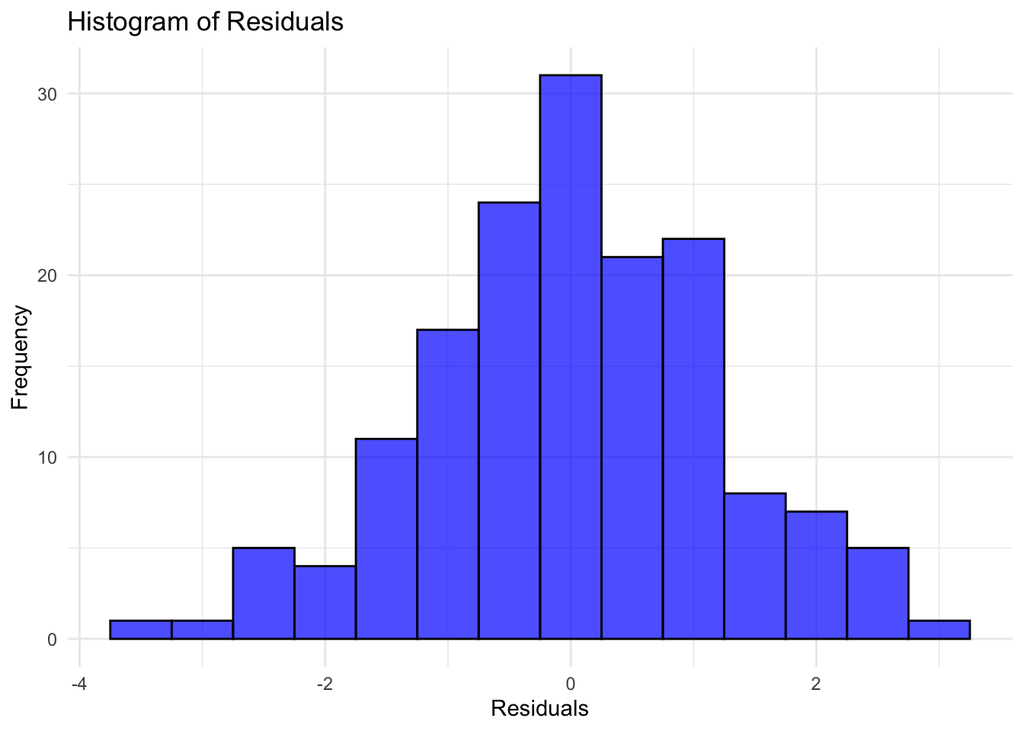

```r
# Calculate residuals
residuals_model2 <- residuals(new_model_complex)

# Plot histogram
ggplot(data.frame(residuals2 = residuals_model2), aes(x = residuals2)) +
  geom_histogram(binwidth = 0.5, color = "black", fill = "blue", alpha = 0.7) +
  labs(title = "Histogram of Residuals", x = "Residuals", y = "Frequency") +
  theme_minimal()
```

```r
# Shapiro-Wilk normality test
shapiro.test(residuals_model2)
```

```
##
##  Shapiro-Wilk normality test
##
## data:  residuals_model2
## W = 0.99446, p-value = 0.8154
```

Linearity assumption

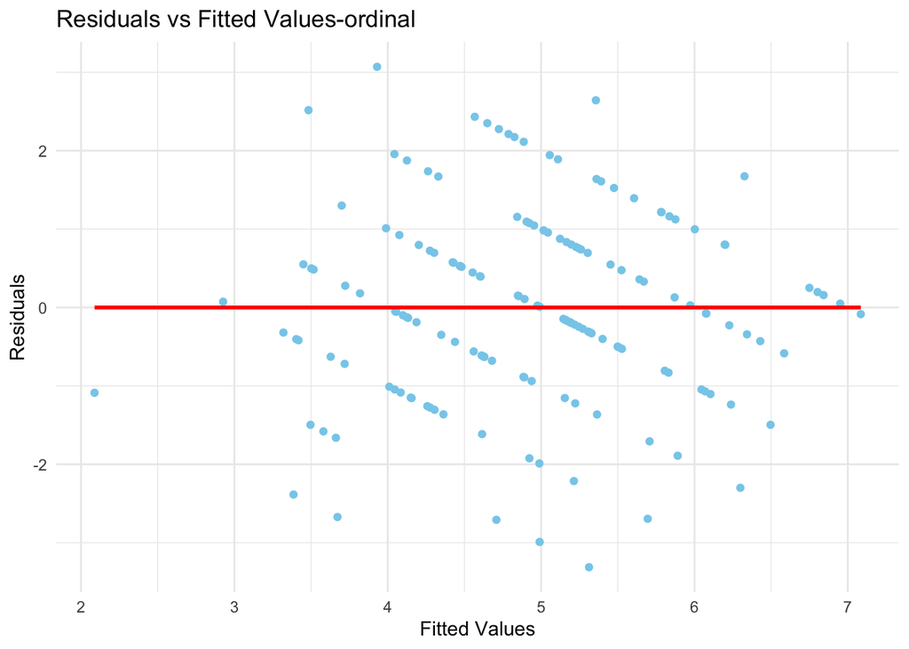

```r
# Get the fitted  values
fitted_values2 <- fitted(new_model_complex)

# Create a data frame for ggplot
residuals_vs_fitted_df2 <- data.frame(fitted_values2, residuals2 = residuals(new_model_complex))

# Residuals vs Fitted plot using ggplot2
ggplot(residuals_vs_fitted_df2, aes(x = fitted_values2, y = residuals2)) +
  geom_point(color = "skyblue") +
  geom_smooth(method = "lm", color = "red", se = FALSE) +  # Optional: Add a linear trend line
  labs(title = "Residuals vs Fitted Values-ordinal", x = "Fitted Values", y = "Residuals") +
  theme_minimal()
```

Homoscedasticty assumption (homogeneity of variance)

```r
# Breusch-Pagan Test for homoscedasticity for new model
bptest(new_model_complex)
```

```
##
##  studentized Breusch-Pagan test
##
## data:  new_model_complex
## BP = 6.7657, df = 6, p-value = 0.3431
```

Multicollinearity assumption

```r
# Calculate and check the VIF for the new complex model
vif_values <- vif(new_model_complex)

# Print VIF values
print(vif_values)
```

```
##             age             sex      STAI_trait        pain_cat     mindfulness
##        1.524011        1.133221        2.038473        1.744606        1.466532
## cortisol_saliva
##        1.679635
```

## Model comparison

Create the simple model and get the results of the model that needs to be reported based on the What to report section.

```r
# Simple model with age and sex
model_simple <- lm(pain ~ age + sex, data = final_dataset)
summary(model_simple)
```

```
##
## Call:
## lm(formula = pain ~ age + sex, data = final_dataset)
##
## Residuals:
##     Min      1Q  Median      3Q     Max
## -3.6729 -0.9614  0.1113  1.0105  3.4493
##
## Coefficients:
##             Estimate Std. Error t value Pr(>|t|)
## (Intercept)  8.30568    0.95157   8.728 3.85e-15 ***
## age         -0.08448    0.02313  -3.653 0.000355 ***
## sexmale      0.13129    0.23235   0.565 0.572853
## ---
## Signif. codes:  0 '***' 0.001 '**' 0.01 '*' 0.05 '.' 0.1 ' ' 1
##
## Residual standard error: 1.458 on 155 degrees of freedom
## Multiple R-squared:  0.08041,    Adjusted R-squared:  0.06855
## F-statistic: 6.777 on 2 and 155 DF,  p-value: 0.001508
```

Create the more complex model based on the results of the model diagnostics. Also, get the results that needs to be reported based on the What to report section.

```r
# Final-complex  model with multiple predictors
final_model <- lm(pain ~ age + sex + STAI_trait + pain_cat + mindfulness + cortisol_saliva, data = final_dataset)
summary(final_model)
```

```
##
## Call:
## lm(formula = pain ~ age + sex + STAI_trait + pain_cat + mindfulness +
##     cortisol_saliva, data = final_dataset)
##
## Residuals:
##     Min      1Q  Median      3Q     Max
## -3.3126 -0.7090 -0.0763  0.7986  3.0697
##
## Coefficients:
##                 Estimate Std. Error t value Pr(>|t|)
## (Intercept)      1.26406    1.72528   0.733 0.464897
## age             -0.01983    0.02432  -0.815 0.416079
## sexmale          0.31755    0.21067   1.507 0.133814
## STAI_trait      -0.02995    0.02803  -1.068 0.287073
## pain_cat         0.09812    0.02811   3.491 0.000632 ***
## mindfulness     -0.11636    0.12596  -0.924 0.357079
## cortisol_saliva  0.59683    0.12744   4.683 6.24e-06 ***
## ---
## Signif. codes:  0 '***' 0.001 '**' 0.01 '*' 0.05 '.' 0.1 ' ' 1
##
## Residual standard error: 1.242 on 151 degrees of freedom
## Multiple R-squared:  0.3496, Adjusted R-squared:  0.3237
## F-statistic: 13.53 on 6 and 151 DF,  p-value: 2.995e-12
```

Writing everything into tables.

```r
# Get summaries of the models
summary_simple <- summary(model_simple)
summary_final <- summary(final_model)


# Extract test statistics (Adj R², F, df, p-value)
extract_stats <- function(model_summary) {
  adj_r2 <- model_summary$adj.r.squared
  f_stat <- model_summary$fstatistic[1]
  df1 <- model_summary$fstatistic[2]
  df2 <- model_summary$fstatistic[3]
  p_value <- pf(f_stat, df1, df2, lower.tail = FALSE)
  return(c(adj_r2, f_stat, df1, df2, p_value))
}

# Extract statistics for both models
stats_simple <- extract_stats(summary_simple)
stats_final <- extract_stats(summary_final)

# Create model comparison table
model_comparison <- data.frame(
  Model = c("Simple Model", "Final Model"),
  Adjusted_R2 = c(stats_simple[1], stats_final[1]),
  F_statistic = c(stats_simple[2], stats_final[2]),
  DF1 = c(stats_simple[3], stats_final[3]),
  DF2 = c(stats_simple[4], stats_final[4]),
  P_value_F = c(stats_simple[5], stats_final[5])
)

# Extract coefficients for both models
coefs_simple <- summary_simple$coefficients
coefs_final <- summary_final$coefficients

# Create coefficient table
coeff_table <- data.frame(
  Predictor = rownames(coefs_final),
  Unstd_Coeff_Simple = c(coefs_simple[,"Estimate"], rep(NA, nrow(coefs_final) - nrow(coefs_simple))),
  Unstd_Coeff_Final = coefs_final[,"Estimate"],
  P_value_Simple = c(coefs_simple[,"Pr(>|t|)"], rep(NA, nrow(coefs_final) - nrow(coefs_simple))),
  P_value_Final = coefs_final[,"Pr(>|t|)"]
)

# Print model comparison table
print(model_comparison)
```

```
##          Model Adjusted_R2 F_statistic DF1 DF2    P_value_F
## 1 Simple Model   0.0685468    6.776913   2 155 1.508218e-03
## 2  Final Model   0.3237320   13.526079   6 151 2.995288e-12
```

```r
# Print coefficient table
print(coeff_table)
```

```
##                       Predictor Unstd_Coeff_Simple Unstd_Coeff_Final
## (Intercept)         (Intercept)         8.30567882        1.26405585
## age                         age        -0.08448346       -0.01983310
## sexmale                 sexmale         0.13129254        0.31755483
## STAI_trait           STAI_trait                 NA       -0.02994738
## pain_cat               pain_cat                 NA        0.09811980
## mindfulness         mindfulness                 NA       -0.11636089
## cortisol_saliva cortisol_saliva                 NA        0.59682923
##                 P_value_Simple P_value_Final
## (Intercept)       3.851387e-15  4.648965e-01
## age               3.547013e-04  4.160793e-01
## sexmale           5.728529e-01  1.338144e-01
## STAI_trait                  NA  2.870732e-01
## pain_cat                    NA  6.322019e-04
## mindfulness                 NA  3.570793e-01
## cortisol_saliva             NA  6.242223e-06
```

Compare the two models.

```r
# Calculate AIC for the simple model
aic_simple <- AIC(model_simple)

# Calculate AIC for the final complex model
aic_final <- AIC(final_model)

# Print the AIC values for both models
print(paste("AIC for simple model:", aic_simple))
```

```
## [1] "AIC for simple model: 572.476947785307"
```

```r
print(paste("AIC for final model:", aic_final))
```

```
## [1] "AIC for final model: 525.761274520539"
```

```r
# You can also compare directly:
if (aic_simple < aic_final) {
  print("The simple model has a better AIC (lower is better).")
} else {
  print("The final model has a better AIC (lower is better).")
}
```

```
## [1] "The final model has a better AIC (lower is better)."
```